# Prediction: Comparing Tress

Charles Lang

1/9/2018

In this assignment you will modelling student data using three flavors of tree algorithm: CART, C4.5 and C5.0. We will be using these algorithms to attempt to predict which students drop out of courses. Many universities have a problem with students over-enrolling in courses at the beginning of semester and then dropping most of them as the make decisions about which classes to attend. This makes it difficult to plan for the semester and allocate resources. However, schools don’t want to restrict the choice of their students. One solution is to create predictions of which students are likley to drop out of which courses and use these predictions to inform semester planning.

In this assignment we will be using the tree algorithms to build models of which students are likely to drop out of which classes.

## Software

In order to generate our models we will need several packages. The first package you should install is [caret](https://cran.r-project.org/web/packages/caret/index.html). (https://topepo.github.io/caret/train-models-by-tag.html)(https://cran.r-project.org/web/packages/caret/vignettes/caret.pdf)

There are many prediction packages available and they all have slightly different syntax. caret is a package that brings all the different algorithms under one hood using the same syntax.

We will also be accessing an algorithm from the [Weka suite](https://www.cs.waikato.ac.nz/~ml/weka/). Weka is a collection of machine learning algorithms that have been implemented in Java and made freely available by the University of Waikato in New Zealand. To access these algorithms you will need to first install both the [Java Runtime Environment (JRE) and Java Development Kit](http://www.oracle.com/technetwork/java/javase/downloads/jre9-downloads-3848532.html) on your machine. You can then then install the [RWeka](https://cran.r-project.org/web/packages/RWeka/index.html) package within R.

(Issue 1: failure to install RWeka/RWekajars, paste “sudo R CMD javareconf” into terminal and try to install again)

**Weka requires Java and Java causes problems. If you cannot install Java and make Weka work, please follow the alternative instructions at line 121**

The last package you will need is [C50](https://cran.r-project.org/web/packages/C50/index.html)

## Data

The data comes from a university registrar’s office. The code book for the variables are available in the file code-book.txt. Examine the variables and their definitions.

Upload the drop-out.csv data into R as a data frame.

```r
library(tidyverse)
D1 <- read.csv("drop-out.csv", header = TRUE)
str(D1)
```

```
## 'data.frame':    5861 obs. of  10 variables:
##  $ student_id         : int  172777 172777 172777 172777 175658 175658 175658 175658 175658 175658 ...
##  $ years              : int  0 0 0 0 0 5 4 4 0 5 ...
##  $ entrance_test_score: num  47 47 47 47 92.8 92.8 92.8 92.8 92.8 92.8 ...
##  $ courses_taken      : int  4 4 4 4 22 22 22 22 22 22 ...
##  $ complete           : Factor w/ 2 levels "no","yes": 2 2 2 2 2 1 1 1 2 1 ...
##  $ enroll_date_time   : int  159227767 159227782 159227866 159227948 157446419 157446424 157446441 157446449 157446458 157446463 ...
##  $ course_id          : int  807728 658434 658463 658498 807728 658434 658463 658498 807754 658438 ...
##  $ international      : Factor w/ 2 levels "no","yes": 1 1 1 1 1 1 1 1 1 1 ...
##  $ online             : Factor w/ 2 levels "no","yes": 1 1 1 1 1 1 1 1 1 1 ...
##  $ gender             : int  1 1 1 1 1 1 1 1 1 1 ...
```

```r
#D1$enroll_date_time<-as.POSIXct(D1$enroll_date_time,origin=Sys.Date())
```

The next step is to separate your data set into a training set and a test set. Randomly select 25% of the students to be the test data set and leave the remaining 75% for your training data set. (Hint: each row represents an answer, not a single student.)

```r
set.seed(666)

#calculating number of 75% of the students
round(length(unique(D1$student_id))*0.75)
```

```
## [1] 512
```

```r
SAMPLE <- data.frame(sample(unique(D1$student_id), 512))
names(SAMPLE) <- c("student_id")

#adding a dataframe with only the id with inner join to get the rows with common id; anti_inner for the rest
TRAIN1 <- inner_join(D1, SAMPLE, by = "student_id")  # by using join, we can easily match those duplicated id
TEST1 <- anti_join(D1, SAMPLE, by = "student_id")
```

For this assignment you will be predicting the student level variable “complete”. (Hint: make sure you understand the increments of each of your chosen variables, this will impact your tree construction)

```r
# Recoding variables:
## DV complete: numeric 1, 0
## IV international: numeric 1, 0
## IV online: numeric 1, 0
D2 <- D1 %>%
  mutate(complete=ifelse(complete=="yes", 1,0)) %>%
  mutate(international=ifelse(international=="yes", 1,0)) %>%
  mutate(online=ifelse(online=="yes", 1,0))


# what's the point of recoding these variables here?
```

Visualize the relationships between your chosen variables as a scatterplot matrix. Save your image as a .pdf named scatterplot_matrix.pdf. Based on this visualization do you see any patterns of interest? Why or why not?

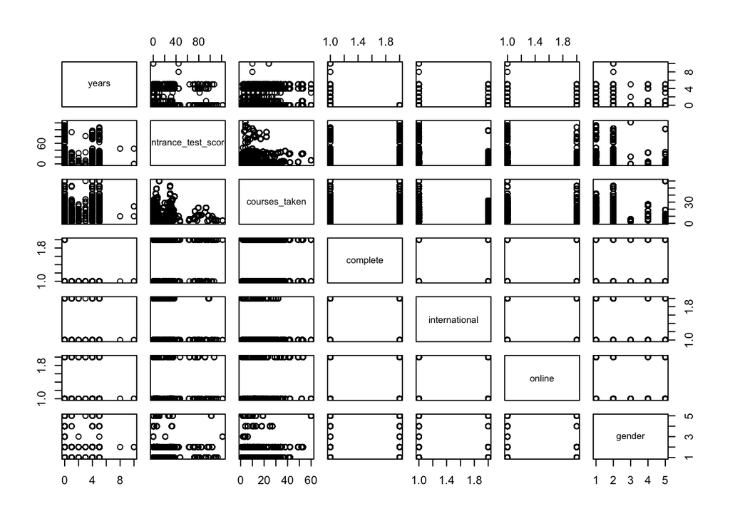

```r
plot(D1[,c(2:5,8:10)])
```

```r
pdf("scatterplot_matrix.pdf")

dev.off()
```

```r
# 1. "years" and "complete": As observed, the fewer years student spent in the program, the more likely he or she would complete. Thus, there exists a possibile negative relationship between these two variables.

# 2. "entrance_test_score" and "complete":  As observed, the higher entrance test score student has, the more likely he or she would complete.

# 3. "course_taken" and "complete": As observed, the fewer courses student took, there is higher chance he or she would complete.

# 4. "entrance_test_score" and "courses_taken": there is a seemingly negative relationship, that students who have taken more courses are more likely to have a lower entrance exam test score.

# 5. "years" and "entrance_test_score": As observed, students with with higher entrance exam test score spent fewer years in the program.

# 6. "years" and "online" : As observed, students who have taken online courses spent fewer years in the program.

# 7. "years" and "international" : As observed, international students have taken fewer years than non-international students.
```

## CART Trees

In HUDK4050 we used the [rpart package](https://cran.r-project.org/web/packages/rpart/rpart.pdf) to generate CART tree models. Review your work using this package if you cannot remember how the trees are constructed.

Construct a classification tree that predicts complete using the caret package.

```r
library(caret)
```

```r
TRAIN2 <- TRAIN1[,c(2:10)] #Remove the student_id variable that we do not want to use in the model

#Define the control elements we would like to use
ctrl <- trainControl(method = "repeatedcv", #Tell caret to perform 10-fold cross validation
                repeats = 3, #Tell caret to repeat each fold three times
                classProbs = TRUE, #Calculate class probabilities for ROC calculation
                summaryFunction = twoClassSummary)

#Define the model
cartFit <- train(complete ~ ., #Define which variable to predict
                data = TRAIN2, #Define the data set to train the model on
                trControl = ctrl, #Tell caret the control elements (EG - the cross validation)
                method = "rpart", #Define the model type
                metric = "ROC", #Tell caret to calculate the ROC curve
                preProc = c("center", "scale")) #Center and scale the data to minimize the ?? what?

#Check the results
cartFit
```

```
## CART
##
## 4292 samples
##    8 predictor
##    2 classes: 'no', 'yes'
##
## Pre-processing: centered (8), scaled (8)
## Resampling: Cross-Validated (10 fold, repeated 3 times)
## Summary of sample sizes: 3862, 3863, 3862, 3862, 3862, 3863, ...
## Resampling results across tuning parameters:
##
##   cp          ROC        Sens       Spec
##   0.01026046  0.8882883  0.6569512  0.9953719
##   0.03314917  0.8386731  0.6111486  0.9973557
##   0.57774270  0.6182613  0.2365225  1.0000000
##
## ROC was used to select the optimal model using the largest value.
## The final value used for the model was cp = 0.01026046.
```

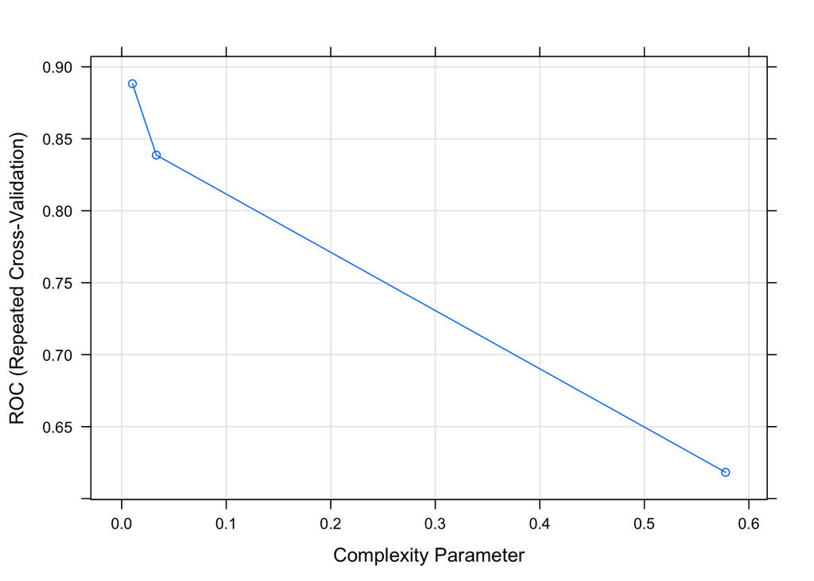

```r
#Plot ROC against complexity
plot(cartFit)
```

Describe important model attribues of your tree. Do you believe it is a successful model of student performance, why/why not?

However, the sensitivity, which is true positive / true positive + true negative, of the model is 0.6569512. This means that the proportion of positive identifications of students who have completed was actually correct is only 65.69%. This implies that some students, who have completed the course, where incorrectly classified as “not completed”. In this case, it can be said that this model of student performance is not successful.

What does the plot represent? What information does this plot tell us?

Now predict results from the test data and describe import attributes of this test. Do you believe it is a successful model of student performance, why/why not?

```r
TEST2 <- TEST1[,c(2:10)] #Remove the student_id variable that we do not want to use in the model

#Generate prediction using previously trained model
cartClasses <- predict(cartFit, newdata = TEST2)

#Generate model statistics
confusionMatrix(data = cartClasses, TEST2$complete)
```

```
## Confusion Matrix and Statistics
##
##           Reference
## Prediction   no  yes
##        no   296    3
##        yes  161 1109
##
##                Accuracy : 0.8955
##                  95% CI : (0.8793, 0.9102)
##     No Information Rate : 0.7087
##     P-Value [Acc > NIR] : < 2.2e-16
##
##                   Kappa : 0.7181
##
##  Mcnemar's Test P-Value : < 2.2e-16
##
##             Sensitivity : 0.6477
##             Specificity : 0.9973
##          Pos Pred Value : 0.9900
##          Neg Pred Value : 0.8732
##              Prevalence : 0.2913
##          Detection Rate : 0.1887
##    Detection Prevalence : 0.1906
##       Balanced Accuracy : 0.8225
##
##        'Positive' Class : no
##
```

## Alternative to Weka - if you made Weka work you can skip to line 179

Train a Conditional Inference Tree using the `party` package on the same training data and examine your results.

```r
ctrl <- trainControl(method = "repeatedcv",
                repeats = 3,
                classProbs = TRUE,
                summaryFunction = twoClassSummary)

ctreeFit <- train(complete ~ .,
                data = TRAIN2,
                trControl = ctrl,
                method = "ctree",
                metric = "ROC",
                preProc = c("center", "scale"))

ctreeFit
```

```
## Conditional Inference Tree
##
## 4292 samples
##    8 predictor
##    2 classes: 'no', 'yes'
##
## Pre-processing: centered (8), scaled (8)
## Resampling: Cross-Validated (10 fold, repeated 3 times)
## Summary of sample sizes: 3863, 3864, 3862, 3863, 3862, 3863, ...
## Resampling results across tuning parameters:
##
##   mincriterion  ROC        Sens       Spec
##   0.01          0.9083616  0.7079948  0.9678283
##   0.50          0.9124419  0.6729930  0.9943796
##   0.99          0.9028649  0.6572074  0.9994481
##
## ROC was used to select the optimal model using the largest value.
## The final value used for the model was mincriterion = 0.5.
```

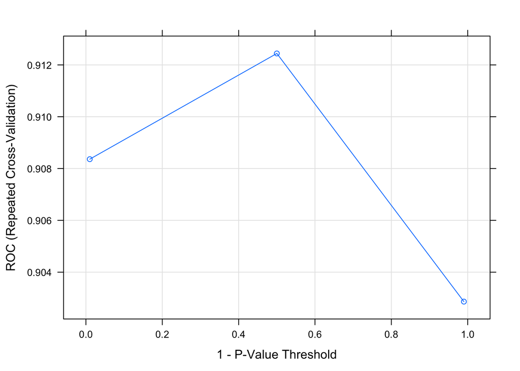

```r
plot(ctreeFit)
```

Describe important model attribues of your tree. Do you believe it is a successful model of student performance, why/why not?

First, the final mincriterion value that was used for this model was 0.5 . The ROC value of this model is 0.9124419, which means that there is a 91.24% probability of a randomly selected student from a “completed” group being positioned as “completed” to a randomly selected student from a “not completed” group being positioned as “completed”. This ROC value is fairly high, and higher than that of the CART model.

Second, the specificity, which is true negative / true positive + true negative, of the model is 0.9943796 This means that the proportion of negative identifications of students who have not completed was actually correct is 99.43%. There is a slight decrease frm that of the CART model.

However, the sensitivity, which is true positive / true positive + true negative, of the model is 0.6729930 This means that the proportion of positive identifications of students who have completed was actually correct is only 67.29%. There is a slight increase frm that of the CART model.

Overall, this model is better at predicting student performance than the CART model.

What does the plot represent? What information does this plot tell us? The plot shows a peak at the middle of x-axis, indicating that when mincriterion equals to .5, the ROC can reach its highest value and making it the optimal cutoff for this model in predicting the “complete” outcome.

Now test your new Conditional Inference model by predicting the test data and generating model fit statistics.

```r
#Generate prediction using previously trained model
ctreeClasses <- predict(ctreeFit, newdata = TEST2)

#Generate model statistics
confusionMatrix(data =ctreeClasses, TEST2$complete)
```

```
## Confusion Matrix and Statistics
##
##           Reference
## Prediction   no  yes
##        no   306   13
##        yes  151 1099
##
##                Accuracy : 0.8955
##                  95% CI : (0.8793, 0.9102)
##     No Information Rate : 0.7087
##     P-Value [Acc > NIR] : < 2.2e-16
##
##                   Kappa : 0.7221
##
##  Mcnemar's Test P-Value : < 2.2e-16
##
##             Sensitivity : 0.6696
##             Specificity : 0.9883
##          Pos Pred Value : 0.9592
##          Neg Pred Value : 0.8792
##              Prevalence : 0.2913
##          Detection Rate : 0.1950
##    Detection Prevalence : 0.2033
##       Balanced Accuracy : 0.8289
##
##        'Positive' Class : no
##
```

##The C50 Tree

There is an updated version of the C4.5 model called C5.0, it is implemented in the C50 package. What improvements have been made to the newer version?

Accuracy: The C5.0 rulesets have noticeably lower error rates on unseen cases for the sleep and forest datasets. The C4.5 and C5.0 rulesets have the same predictive accuracy for the income dataset, but the C5.0 ruleset is smaller.

Speed: C5.0 is much faster; it uses different algorithms and is highly optimized. For instance, C4.5 required more than eight hours to find the ruleset for forest, but C5.0 completed the task in under three minutes

Memory: C5.0 commonly uses an order of magnitude less memory than C4.5 during ruleset construction. For the forest dataset, C4.5 needs more than 3GB but C5.0 requires less than 200MB.

C5.0’s trees are noticeably smaller on the tree sizes and computation times. C5.0 supports boosting with any number of trials, with more trials generally yielding further improvements.Boosting is a technique for generating and combining multiple classifiers to improve predictive accuracy.

Install the C50 package, train and then test the C5.0 model on the same data.

```r
c50Fit <- train(complete ~ .,
                data = TRAIN2,
                trControl = ctrl,
                method = "C5.0",
                metric = "ROC",
                preProc = c("center", "scale"))

c50Fit
```

```
## C5.0
##
## 4292 samples
##    8 predictor
##    2 classes: 'no', 'yes'
##
## Pre-processing: centered (8), scaled (8)
## Resampling: Cross-Validated (10 fold, repeated 3 times)
## Summary of sample sizes: 3863, 3862, 3863, 3863, 3864, 3864, ...
## Resampling results across tuning parameters:
##
##   model  winnow  trials  ROC        Sens       Spec
##   rules  FALSE    1      0.8323179  0.6672062  0.9930577
##   rules  FALSE   10      0.9208586  0.6756155  0.9883206
##   rules  FALSE   20      0.9223974  0.6732533  0.9909623
##   rules   TRUE    1      0.8317821  0.6661521  0.9931680
##   rules   TRUE   10      0.9207415  0.6729763  0.9890918
##   rules   TRUE   20      0.9217035  0.6714077  0.9919561
##   tree   FALSE    1      0.8824203  0.6708891  0.9925072
##   tree   FALSE   10      0.9194651  0.6745511  0.9877640
##   tree   FALSE   20      0.9224638  0.6771945  0.9886510
##   tree    TRUE    1      0.8820169  0.6703600  0.9926176
##   tree    TRUE   10      0.9187646  0.6726992  0.9895300
##   tree    TRUE   20      0.9221093  0.6766654  0.9889789
##
## ROC was used to select the optimal model using the largest value.
## The final values used for the model were trials = 20, model = tree and winnow
##  = FALSE.
```

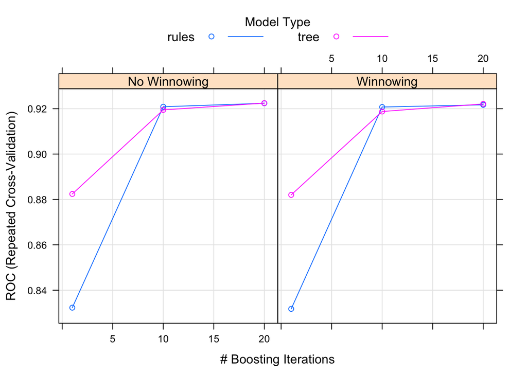

```r
plot(c50Fit)
```

```r
c50Classes <- predict(c50Fit, newdata = TEST2)

confusionMatrix(data = c50Classes, TEST2$complete)
```

```
## Confusion Matrix and Statistics
##
##           Reference
## Prediction   no  yes
##        no   318   29
##        yes  139 1083
##
##                Accuracy : 0.8929
##                  95% CI : (0.8766, 0.9078)
##     No Information Rate : 0.7087
##     P-Value [Acc > NIR] : < 2.2e-16
##
##                   Kappa : 0.7209
##
##  Mcnemar's Test P-Value : < 2.2e-16
##
##             Sensitivity : 0.6958
##             Specificity : 0.9739
##          Pos Pred Value : 0.9164
##          Neg Pred Value : 0.8863
##              Prevalence : 0.2913
##          Detection Rate : 0.2027
##    Detection Prevalence : 0.2212
##       Balanced Accuracy : 0.8349
##
##        'Positive' Class : no
##
```

## Compare the models

caret allows us to compare all three models at once.

```r
resamps <- resamples(list(cart = cartFit, ctree = ctreeFit, c50 = c50Fit))
summary(resamps)
```

```
##
## Call:
## summary.resamples(object = resamps)
##
## Models: cart, ctree, c50
## Number of resamples: 30
##
## ROC
##            Min.   1st Qu.    Median      Mean   3rd Qu.      Max. NA's
## cart  0.8540700 0.8806199 0.8886186 0.8882883 0.8953994 0.9192552    0
## ctree 0.8800516 0.9050877 0.9100264 0.9124419 0.9241213 0.9414646    0
## c50   0.8971921 0.9179032 0.9220232 0.9224638 0.9305186 0.9419226    0
##
## Sens
##            Min.   1st Qu.    Median      Mean   3rd Qu.      Max. NA's
## cart  0.5905512 0.6377953 0.6614173 0.6569512 0.6746032 0.7380952    0
## ctree 0.5905512 0.6435602 0.6692913 0.6729930 0.7047244 0.7777778    0
## c50   0.6141732 0.6627297 0.6732283 0.6771945 0.6891170 0.7301587    0
##
## Spec
##            Min.   1st Qu.    Median      Mean   3rd Qu. Max. NA's
## cart  0.9867987 0.9933775 0.9966887 0.9953719 0.9966997    1    0
## ctree 0.9834437 0.9900744 0.9950495 0.9943796 1.0000000    1    0
## c50   0.9702970 0.9834983 0.9900990 0.9886510 0.9933993    1    0
```

What does the model summary tell us? Which model do you believe is the best?

The summary gives us the 5 number summary of each model regarding to ROC, Sensitivity and Specificity. Ad for the best model, it shoud be performing most stably with less variance in the parameters. Here I use eyeballing and mean as equipment to determine which model is stabler.

In Specificity, three models differ no significantly. In Sensitivity and ROC, ctree and c50 are slightly better than cart.

Which variables (features) within your chosen model are important, do these features provide insights that may be useful in solving the problem of students dropping out of courses?

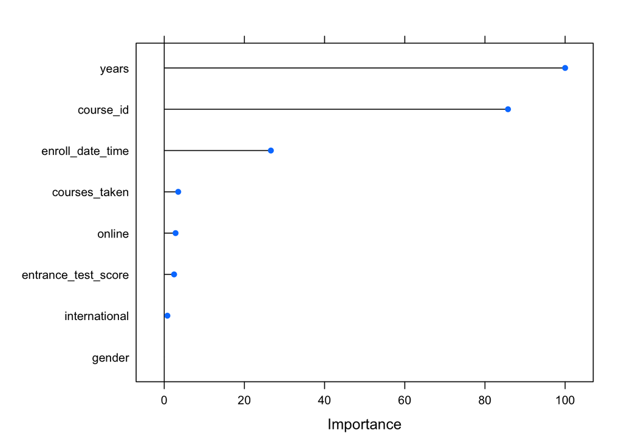

```r
#looking at variables that are important in the model.
variables <- varImp(ctreeFit)
plot(variables)
```

```r
# It shows in the plot that "years" and "course_id"are important, which all make sense since the longer time a student have spent in a program, a more possible learning difficulty is indicated; some courses are not so "student friendly" that fail student easily;
```